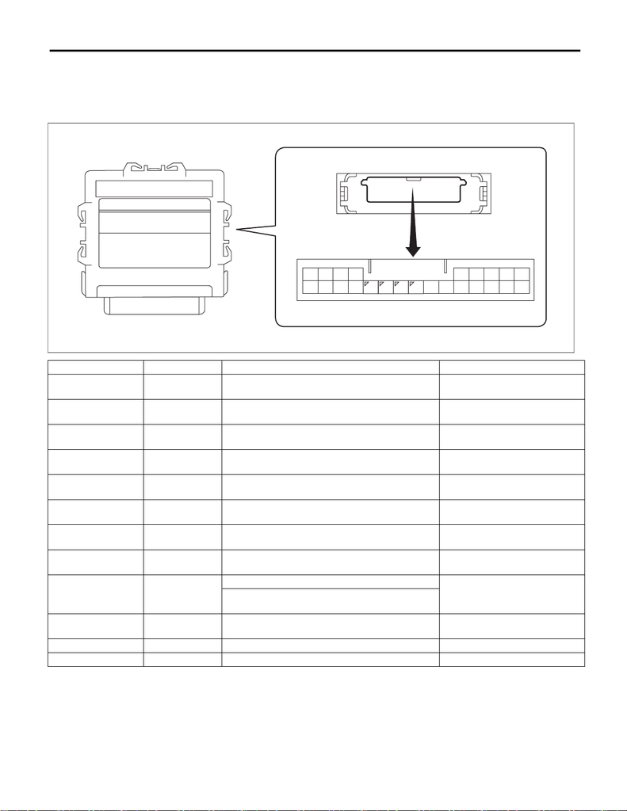

AL(diag)-6

Control Module I/O Signal

AUTO HEADLIGHT BEAM LEVELER SYSTEM (DIAGNOSTICS)

5. Control Module I/O Signal

A: ELECTRICAL SPECIFICATION

1. AUTO HEADLIGHT BEAM LEVELER CM

B: WIRING DIAGRAM

Refer to “Headlight Beam Leveler System” in the wiring diagram. <Ref. to WI-250, WIRING DIAGRAM,

Headlight Beam Leveler System.>

Contents Terminal No. Measuring condition Standard

IG power supply

1 ←→ Chassis

ground

Ignition switch ON 8 — 16 V

GND

2 ←→ Chassis

ground

Always Less than 1 Ω

Rr vehicle height

sensor GND

3 ←→ Chassis

ground

Always Less than 1 Ω

RH headlight mal-

function signal

5 ←→ Chassis

ground

Always 1 MΩ or more

Leveling actuator

power supply

10 ←→ Chassis

ground

Ignition switch ON 10 — 16 V

Leveling actuator

GND

11 ←→ Chassis

ground

Always Less than 1 Ω

Rr vehicle height

sensor power supply

12 ←→ 3 Ignition switch ON 4.75 — 5.25 V

LH headlight mal-

function signal

16 ←→ Chassis

ground

Always 1 MΩ or more

Leveling actuator sig-

nal

17 ←→ Chassis

ground

Headlight off → on

Less than 1 V → 1.0 — 14.4 V

(for 17 seconds)

Headlight on, no vehicle height change → change

and hold vehicle height for 3 seconds or more

Rr sensor signal

19 ←→ Chassis

ground

IG ON (with no passenger, no load and vehicle

stopped)

Approx. 2.5 V (changes accord-

ing to vehicle condition)

CAN-H 23 Cannot be measured (CAN communication line) —

CAN-L 24 Cannot be measured (CAN communication line) —

LI-00975

24

9

23

8

22

7

6

14

5

13

4

12

3

11

2

10

1